# Case 1 - 4intelligence

Catarina Oliveira Guimarães Barcelos

01/12/2020

```r
rm(list=ls())
```

- Install and load the necessaries packages for doing the exercice

```r
if(!require(fpp2)){install.packages("fpp2", dependencies = TRUE); library(fpp2)}
```

```r
if(!require(forecast)){install.packages("forecast", dependencies = TRUE); library(forecast)}
if(!require(ggplot2)){install.packages("ggplot2", dependencies = TRUE); library(ggplot2)}
if(!require(dplyr)){install.packages("dplyr", dependencies = TRUE); library(dplyr)}
if(!require(readxl)){install.packages("readxl", dependencies = TRUE); library(readxl)}
if(!require(plotly)){install.packages("plotly", dependencies = TRUE); library(plotly)}
if(!require(purrr)){install.packages("purrr", dependencies = TRUE); library(purrr)}
if(!require(cluster)){install.packages("cluster", dependencies = TRUE); library(cluster)}
```

- Indicate the directory

```r
setwd("C:/Users/barce/OneDrive/Ambiente de Trabalho/Challenge_4i/")
```

- Check if R is using the correct paste

```r
getwd()
```

```
## [1] "C:/Users/barce/OneDrive/Ambiente de Trabalho/Challenge_4i"
```

- Load and view the data

```r
data <- read.csv("TFP.csv")
View(data)
```

# Make an exploratory data analysis;

## Preliminary Analysis - See the data of the exercice in a graph

- The Graph 1 below shows the national price constants for the United States, Canada and Mexico between 1950 and 2011, in which the price for 2005 represents the currency in the graph (equal to 1). Each country have strong trends. It is interesting to investigate some transformations. For Canada, the curve is relatively stable over the period, with growth between the 1960s and 1970s, and between the 1990s and 2000s, which represented the periods of the oil crisis and the global fiscal crisis, respectively. In Mexico, prices have risen sharply between the 1950s and the mid-1970s, possibly due to increased population consumption and some global crises in the middle of this path. After that period, the price remains falling. And, finally, in the United States, the national price constant is increasing throughout practically its entire trajectory, becoming more accentuated from the 1980s.

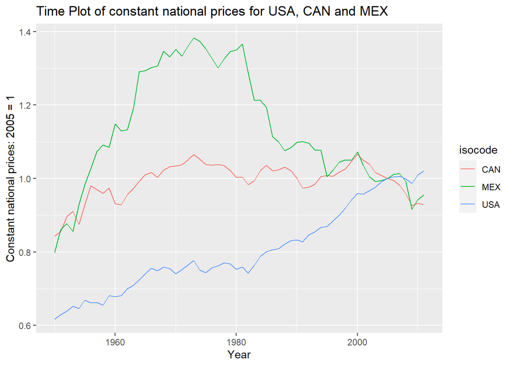

```r
data %>% group_by(isocode) %>% ggplot(aes(year,rtfpna,color= isocode)) +
  geom_line()+ ggtitle("Time Plot of constant national prices for USA, CAN and MEX")+
  ylab("Constant national prices: 2005 = 1")+xlab("Year")
```

# Separate data per each isocode in order to work individually in the three countries

```r
mex <- data %>% filter(isocode=='MEX')# %>% select(-isocode)
can <- data %>% filter(isocode=='CAN') #%>% select(-isocode)
usa <- data %>% filter(isocode=='USA') #%>% select(-isocode)
```

# Declare each data per country as time series data

```r
m <- ts(mex[,3],start= c(1950,1), frequency = 1)
c <- ts(can[,3],start= c(1950,1), frequency = 1)
u <- ts(usa[,3],start= c(1950,1), frequency = 1)
```

### ACF and PACF

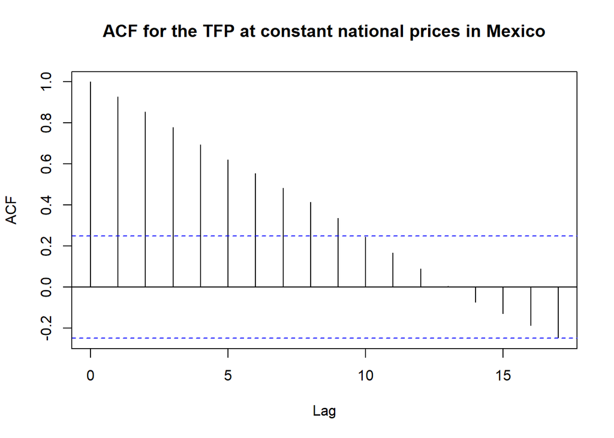

```r
acf(m, main = "ACF for the TFP at constant national prices in Mexico")
```

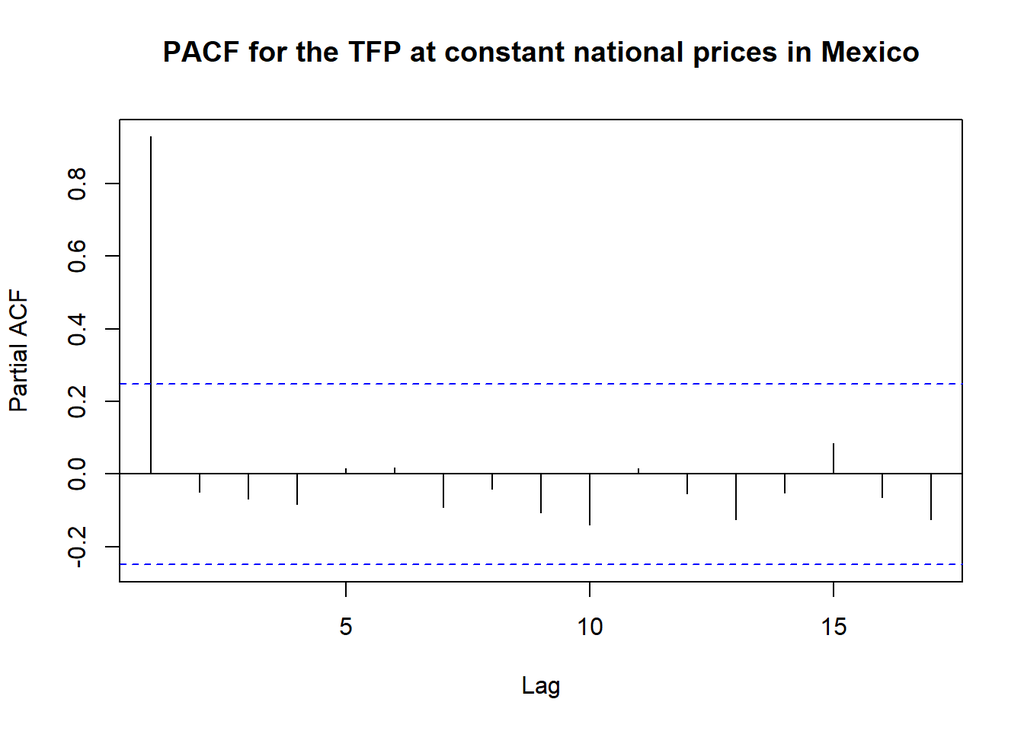

```r
pacf(m, main = "PACF for the TFP at constant national prices in Mexico")
```

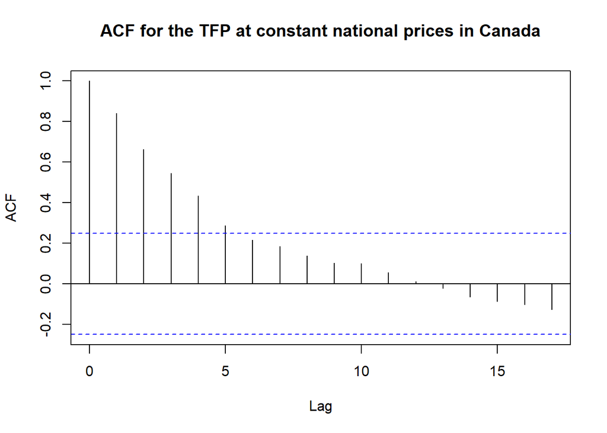

```r
acf(c, main = "ACF for the TFP at constant national prices in Canada")
```

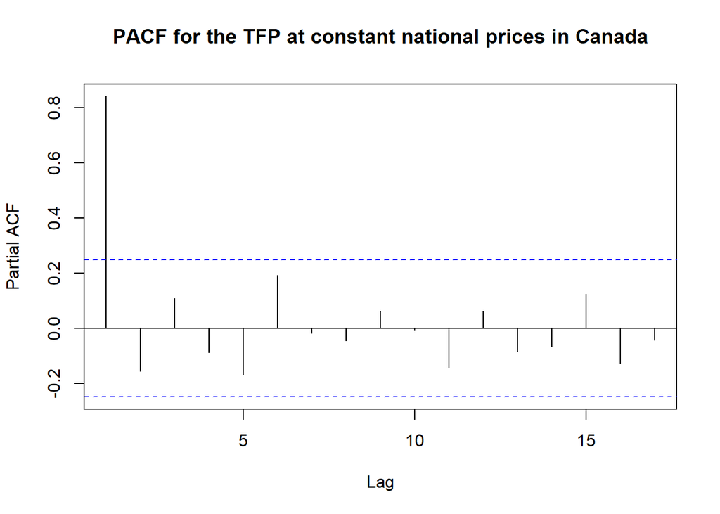

```r
pacf(c, main = "PACF for the TFP at constant national prices in Canada")
```

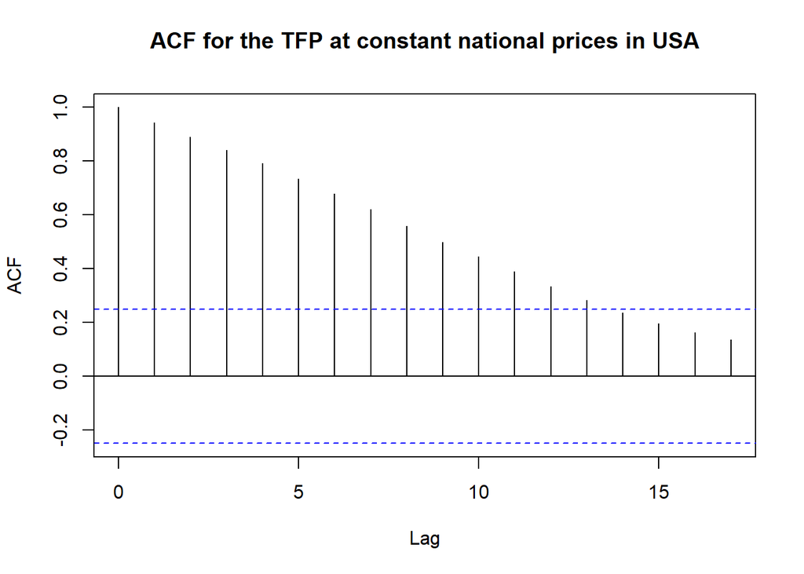

```r
acf(u, main = "ACF for the TFP at constant national prices in USA")
```

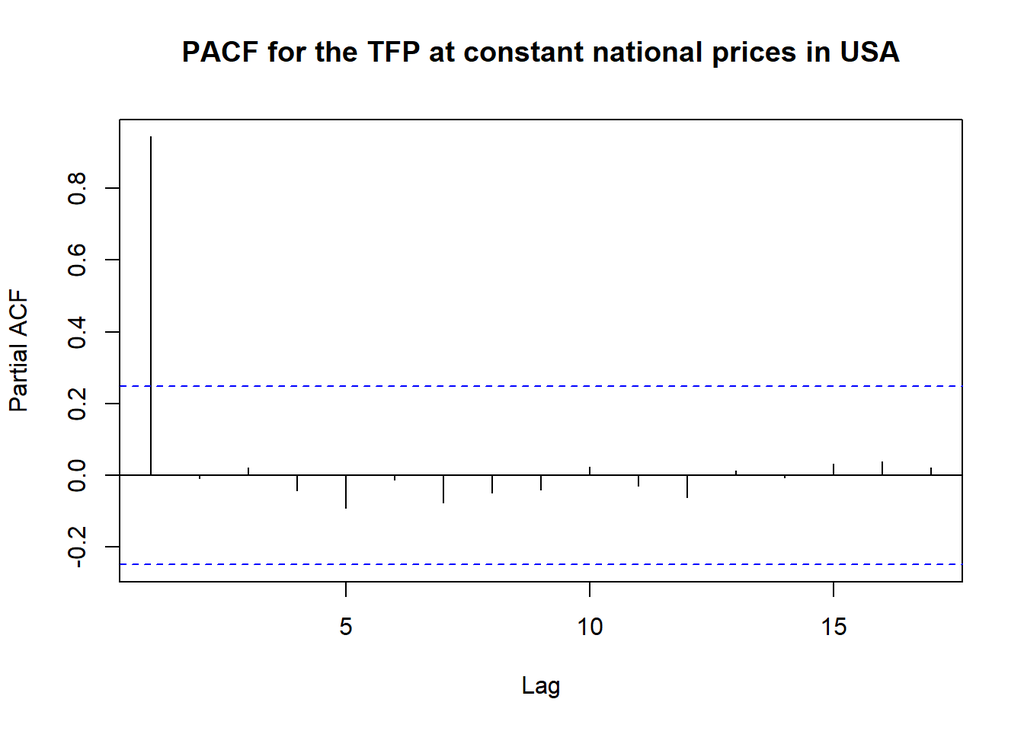

```r
pacf(u, main = "PACF for the TFP at constant national prices in USA")
```

# Forecast 10 years of the series

- In order to face the problem of multicollinearity, we will observe 3 efficient methods: time series benchmark test, ETS and ARIMA presented below. The model chosen for each country was the one with the least error.

### Time Series Benchmark test

- Take the first difference of the data to remove trend

```r
dm <- diff(m)
dc <- diff(c)
du <- diff(u)
```

- Time plot of the difference data
- Observing the first differences in each country, we can see that for all the three countries, the residues seem more random than that observed in Graph 1 once we remove the trend.

### Mexico

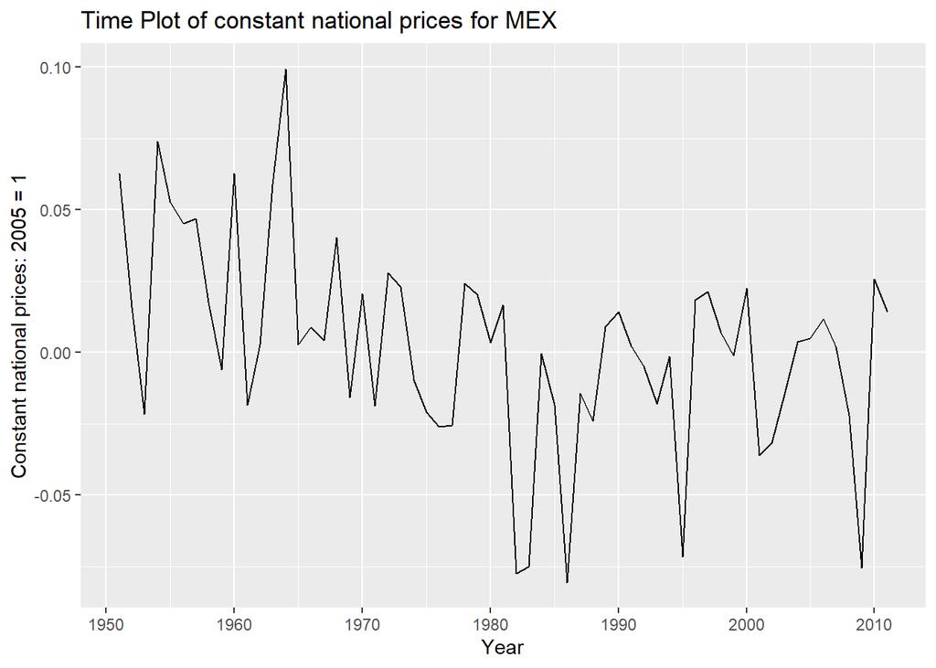

```r
autoplot(dm)+
  ggtitle("Time Plot of constant national prices for MEX")+
  ylab("Constant national prices: 2005 = 1")+xlab("Year")
```

### Canada

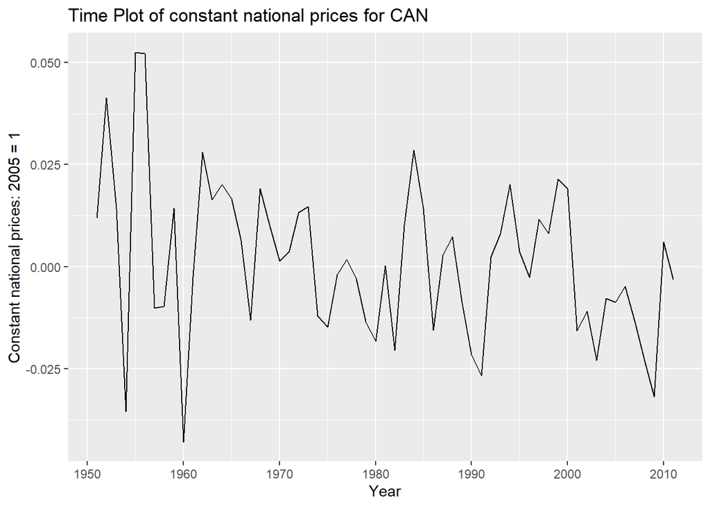

```r
autoplot(dc)+
  ggtitle("Time Plot of constant national prices for CAN")+
  ylab("Constant national prices: 2005 = 1")+xlab("Year")
```

### USA

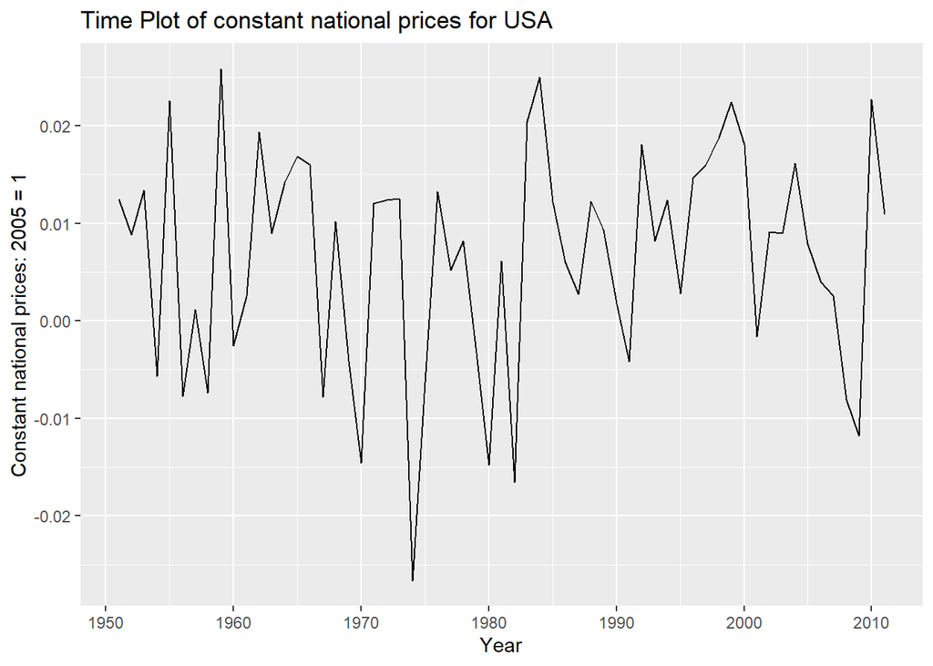

```r
autoplot(du)+
  ggtitle("Time Plot of constant national prices for USA")+
  ylab("Constant national prices: 2005 = 1")+xlab("Year")
```

### Benchmark

```r
fitm <- snaive(dm)  # Residual = 0.043
print(summary(fitm))
```

```
##
## Forecast method: Seasonal naive method
##
## Model Information:
## Call: snaive(y = dm)
##
## Residual sd: 0.043
##
## Error measures:
##                         ME       RMSE        MAE       MPE     MAPE MASE
## Training set -0.0008101682 0.04303332 0.03202372 -235.3912 485.5608    1
##                    ACF1
## Training set -0.3668271
##
## Forecasts:
##      Point Forecast       Lo 80      Hi 80       Lo 95      Hi 95
## 2012       0.014162 -0.04098742 0.06931142 -0.07018175 0.09850576
## 2013       0.014162 -0.06383105 0.09215506 -0.10511808 0.13344209
##      Point Forecast       Lo 80      Hi 80       Lo 95      Hi 95
## 2012       0.014162 -0.04098742 0.06931142 -0.07018175 0.09850576
## 2013       0.014162 -0.06383105 0.09215506 -0.10511808 0.13344209
```

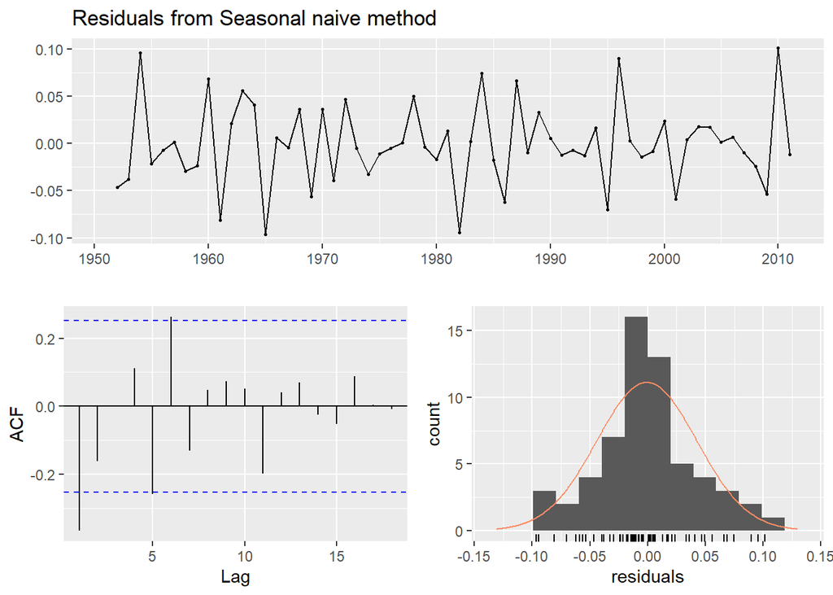

```
##
##  Ljung-Box test
##
## data:  Residuals from Seasonal naive method
## Q* = 22.253, df = 10, p-value = 0.01387
##
## Model df: 0.   Total lags used: 10
```

```r
checkresiduals(fitm)
```

```r
fitc <- snaive(dc) # Residual = 0.0239
print(summary(fitc))
```

```
##
## Forecast method: Seasonal naive method
##
## Model Information:
## Call: snaive(y = dc)
##
## Residual sd: 0.0239
##
## Error measures:
##                         ME       RMSE      MAE      MPE     MAPE MASE
## Training set -0.0002491564 0.02386741 0.017088 240.9282 384.9435    1
##                    ACF1
## Training set -0.2615069
##
## Forecasts:
##      Point Forecast       Lo 80      Hi 80       Lo 95      Hi 95
## 2012   -0.003161192 -0.03374851 0.02742613 -0.04994047 0.04361808
## 2013   -0.003161192 -0.04641820 0.04009581 -0.06931707 0.06299469
##      Point Forecast       Lo 80      Hi 80       Lo 95      Hi 95
## 2012   -0.003161192 -0.03374851 0.02742613 -0.04994047 0.04361808
## 2013   -0.003161192 -0.04641820 0.04009581 -0.06931707 0.06299469
```

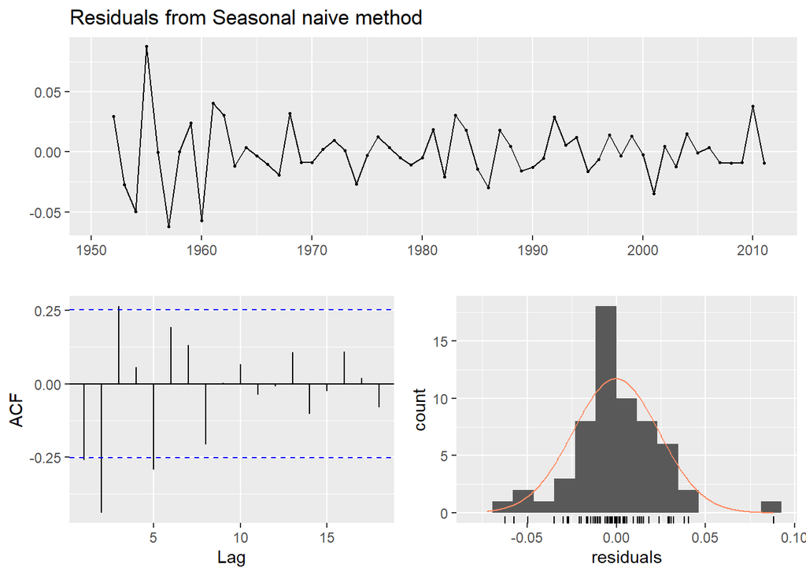

```
##
##  Ljung-Box test
##
## data:  Residuals from Seasonal naive method
## Q* = 34.603, df = 10, p-value = 0.0001459
##
## Model df: 0.   Total lags used: 10
```

```r
checkresiduals(fitc)
```

```r
fitu <- snaive(du) # Residual = 0.0158
print(summary(fitu))
```

```
##
## Forecast method: Seasonal naive method
##
## Model Information:
## Call: snaive(y = du)
##
## Residual sd: 0.0158
##
## Error measures:
##                         ME      RMSE        MAE      MPE    MAPE MASE
## Training set -2.519687e-05 0.0157801 0.01213275 98.10868 174.062    1
##                    ACF1
## Training set -0.4775273
##
## Forecasts:
##      Point Forecast       Lo 80      Hi 80       Lo 95      Hi 95
## 2012     0.01092875 -0.00929426 0.03115176 -0.01999967 0.04185717
## 2013     0.01092875 -0.01767090 0.03952840 -0.03281065 0.05466815
##      Point Forecast       Lo 80      Hi 80       Lo 95      Hi 95
## 2012     0.01092875 -0.00929426 0.03115176 -0.01999967 0.04185717
## 2013     0.01092875 -0.01767090 0.03952840 -0.03281065 0.05466815
```

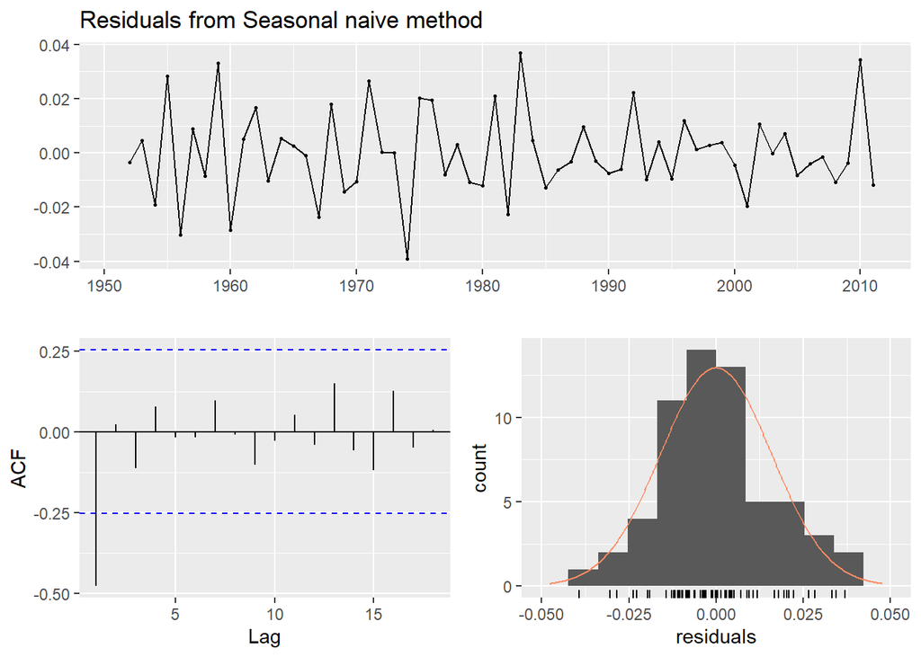

```
##
##  Ljung-Box test
##
## data:  Residuals from Seasonal naive method
## Q* = 17.142, df = 10, p-value = 0.07128
##
## Model df: 0.   Total lags used: 10
```

```r
checkresiduals(fitu)
```

### Fit ETS models

```r
fit_etsm <- ets(m)  # Residual = 0.0298
print(summary(fit_etsm))
```

```
## ETS(M,Ad,N)
##
## Call:
##  ets(y = m)
##
##   Smoothing parameters:
##     alpha = 0.9999
##     beta  = 0.0414
##     phi   = 0.9207
##
##   Initial states:
##     l = 0.7468
##     b = 0.0553
##
##   sigma:  0.0298
##
##       AIC      AICc       BIC
## -158.6524 -157.1251 -145.8896
##
## Training set error measures:
##                        ME       RMSE        MAE        MPE     MAPE     MASE
## Training set -0.005014125 0.03212635 0.02454934 -0.4674131 2.216226 0.925362
##                    ACF1
## Training set 0.07186068
##                        ME       RMSE        MAE        MPE     MAPE     MASE
## Training set -0.005014125 0.03212635 0.02454934 -0.4674131 2.216226 0.925362
##                    ACF1
## Training set 0.07186068
```

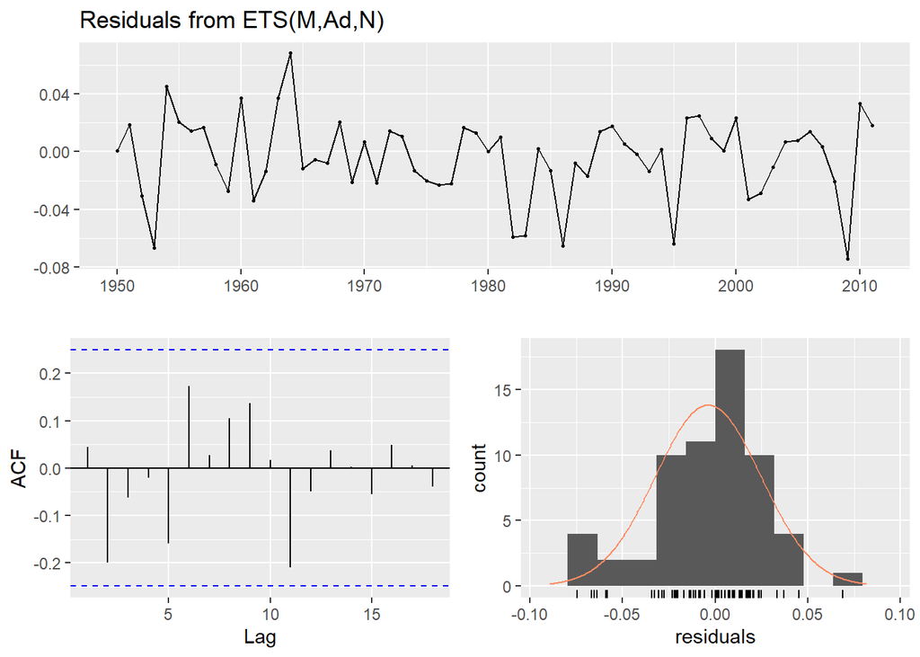

```
##
##  Ljung-Box test
##
## data:  Residuals from ETS(M,Ad,N)
## Q* = 9.2426, df = 5, p-value = 0.09977
##
## Model df: 5.   Total lags used: 10
```

```r
checkresiduals(fit_etsm)
```

```r
fit_etsc <- ets(c)  # Residual = 0.0192
print(summary(fit_etsc))
```

```
## ETS(A,N,N)
##
## Call:
##  ets(y = c)
##
##   Smoothing parameters:
##     alpha = 0.9999
##
##   Initial states:
##     l = 0.8433
##
##   sigma:  0.0192
##
##       AIC      AICc       BIC
## -230.0413 -229.6275 -223.6599
##
## Training set error measures:
##                       ME       RMSE        MAE       MPE    MAPE      MASE
## Training set 0.001388643 0.01892776 0.01479893 0.1372643 1.51184 0.9839152
##                  ACF1
## Training set 0.222846
##                       ME       RMSE        MAE       MPE    MAPE      MASE
## Training set 0.001388643 0.01892776 0.01479893 0.1372643 1.51184 0.9839152
##                  ACF1
## Training set 0.222846
```

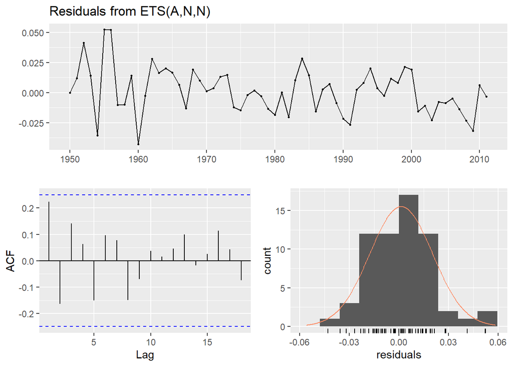

```
##
##  Ljung-Box test
##
## data:  Residuals from ETS(A,N,N)
## Q* = 11.376, df = 8, p-value = 0.1813
##
## Model df: 2.   Total lags used: 10
```

```r
checkresiduals(fit_etsc)
```

```r
fit_etsu <- ets(u)  # Residual = 0.0116
print(summary(fit_etsu))
```

```
## ETS(A,A,N)
##
## Call:
##  ets(y = u)
##
##   Smoothing parameters:
##     alpha = 0.9999
##     beta  = 1e-04
##
##   Initial states:
##     l = 0.6137
##     b = 0.0066
##
##   sigma:  0.0116
##
##       AIC      AICc       BIC
## -291.2946 -290.2232 -280.6589
##
## Training set error measures:
##                         ME       RMSE         MAE         MPE    MAPE      MASE
## Training set -1.359301e-05 0.01118298 0.009069198 -0.02795514 1.16213 0.8038871
##                    ACF1
## Training set 0.02942197
##                         ME       RMSE         MAE         MPE    MAPE      MASE
## Training set -1.359301e-05 0.01118298 0.009069198 -0.02795514 1.16213 0.8038871
##                    ACF1
## Training set 0.02942197
```

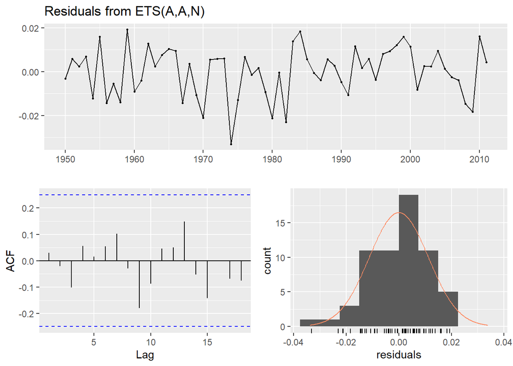

```
##
##  Ljung-Box test
##
## data:  Residuals from ETS(A,A,N)
## Q* = 4.9785, df = 6, p-value = 0.5466
##
## Model df: 4.   Total lags used: 10
```

```r
checkresiduals(fit_etsu)
```

### Fit on ARIMA model

```r
fit_arimam <- auto.arima(m, stepwise= FALSE, approximation=FALSE, trace=TRUE) # Residual = 0.03416138
```

```
##
##  ARIMA(0,2,0)                    : -205.1521
##  ARIMA(0,2,1)                    : -230.442
##  ARIMA(0,2,2)                    : -228.7236
##  ARIMA(0,2,3)                    : -227.9236
##  ARIMA(0,2,4)                    : -228.1489
##  ARIMA(0,2,5)                    : -226.0116
##  ARIMA(1,2,0)                    : -211.7289
##  ARIMA(1,2,1)                    : -228.5481
##  ARIMA(1,2,2)                    : -226.7884
##  ARIMA(1,2,3)                    : -227.9188
##  ARIMA(1,2,4)                    : -229.7372
##  ARIMA(2,2,0)                    : -218.4416
##  ARIMA(2,2,1)                    : -228.1225
##  ARIMA(2,2,2)                    : -228.0939
##  ARIMA(2,2,3)                    : Inf
##  ARIMA(3,2,0)                    : -220.7812
##  ARIMA(3,2,1)                    : -225.8965
##  ARIMA(3,2,2)                    : -225.5935
##  ARIMA(4,2,0)                    : -218.714
##  ARIMA(4,2,1)                    : -223.5142
##  ARIMA(5,2,0)                    : -226.9029
##
##
##
##  Best model: ARIMA(0,2,1)
```

```r
print(summary(fit_arimam))
```

```
## Series: m
## ARIMA(0,2,1)
##
## Coefficients:
##           ma1
##       -0.8502
## s.e.   0.0617
##
## sigma^2 estimated as 0.001167:  log likelihood=117.33
## AIC=-230.65   AICc=-230.44   BIC=-226.46
##
## Training set error measures:
##                        ME       RMSE        MAE        MPE     MAPE     MASE
## Training set -0.004967013 0.03332467 0.02664148 -0.4162653 2.396274 1.004223
##                    ACF1
## Training set 0.04940407
##                        ME       RMSE        MAE        MPE     MAPE     MASE
## Training set -0.004967013 0.03332467 0.02664148 -0.4162653 2.396274 1.004223
##                    ACF1
## Training set 0.04940407
```

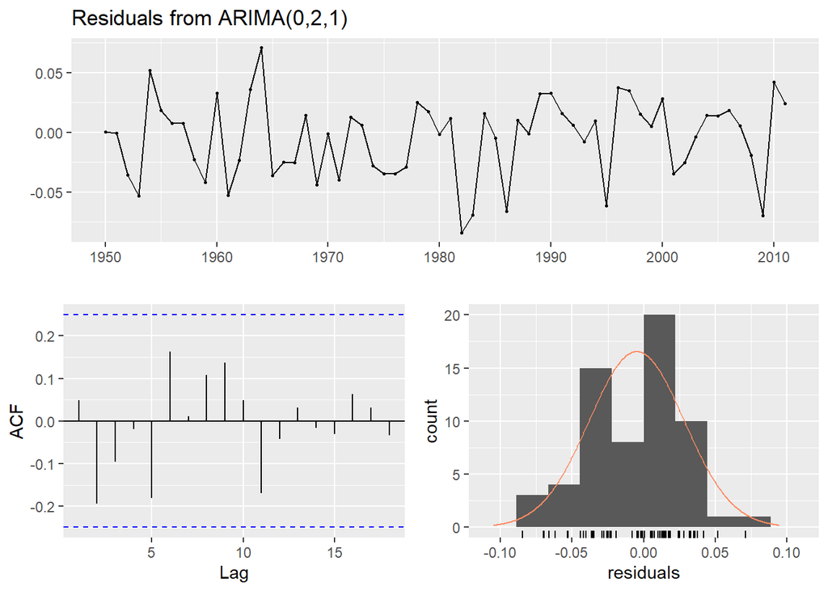

```
##
##  Ljung-Box test
##
## data:  Residuals from ARIMA(0,2,1)
## Q* = 9.8924, df = 9, p-value = 0.3593
##
## Model df: 1.   Total lags used: 10
```

```r
checkresiduals(fit_arimam)
```

```r
sqrt(0.001167)
```

```
## [1] 0.03416138
```

```r
accuracy(fit_arimam)
```

```
##                        ME       RMSE        MAE        MPE     MAPE     MASE
## Training set -0.004967013 0.03332467 0.02664148 -0.4162653 2.396274 1.004223
##                    ACF1
## Training set 0.04940407
```

```r
fit_arimac <- auto.arima(c, stepwise= FALSE, approximation=FALSE, trace=TRUE) # Residual = 0.01783536
```

```
##
##  ARIMA(0,2,0)                    : -275.8873
##  ARIMA(0,2,1)                    : -298.4581
##  ARIMA(0,2,2)                    : -300.954
##  ARIMA(0,2,3)                    : -302.1819
##  ARIMA(0,2,4)                    : -299.838
##  ARIMA(0,2,5)                    : -299.5036
##  ARIMA(1,2,0)                    : -278.0399
##  ARIMA(1,2,1)                    : -298.103
##  ARIMA(1,2,2)                    : -301.0004
##  ARIMA(1,2,3)                    : -299.8109
##  ARIMA(1,2,4)                    : -298.9492
##  ARIMA(2,2,0)                    : -297.8929
##  ARIMA(2,2,1)                    : -300.5447
##  ARIMA(2,2,2)                    : -300.8548
##  ARIMA(2,2,3)                    : -302.2925
##  ARIMA(3,2,0)                    : -296.0067
##  ARIMA(3,2,1)                    : -293.9143
##  ARIMA(3,2,2)                    : -299.4505
##  ARIMA(4,2,0)                    : -294.7219
##  ARIMA(4,2,1)                    : -300.1253
##  ARIMA(5,2,0)                    : -301.3721
##
##
##
##  Best model: ARIMA(2,2,3)
```

```r
print(summary(fit_arimac))
```

```
## Series: c
## ARIMA(2,2,3)
##
## Coefficients:
##          ar1      ar2     ma1      ma2      ma3
##       -0.767  -0.7359  0.1481  -0.2723  -0.6061
## s.e.   0.202   0.1921  0.2337   0.2326   0.1862
##
## sigma^2 estimated as 0.0003181:  log likelihood=157.94
## AIC=-303.88   AICc=-302.29   BIC=-291.31
##
## Training set error measures:
##                        ME       RMSE       MAE        MPE     MAPE      MASE
## Training set -0.003233255 0.01679776 0.0129007 -0.3334222 1.317497 0.8577102
##                      ACF1
## Training set -0.003738827
##                        ME       RMSE       MAE        MPE     MAPE      MASE
## Training set -0.003233255 0.01679776 0.0129007 -0.3334222 1.317497 0.8577102
##                      ACF1
## Training set -0.003738827
```

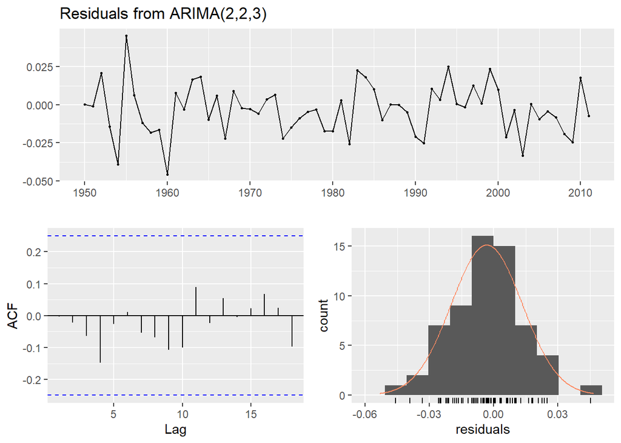

```
##
##  Ljung-Box test
##
## data:  Residuals from ARIMA(2,2,3)
## Q* = 4.0446, df = 5, p-value = 0.543
##
## Model df: 5.   Total lags used: 10
```

```r
checkresiduals(fit_arimac)
```

```r
sqrt(0.0003181)
```

```
## [1] 0.01783536
```

```r
fit_arimau <- auto.arima(u, stepwise= FALSE, approximation=FALSE, trace=TRUE) # Residual = 0.01136222
```

```
##
##  ARIMA(0,1,0)                    : -354.0582
##  ARIMA(0,1,0) with drift         : -369.9663
##  ARIMA(0,1,1)                    : -355.3305
##  ARIMA(0,1,1) with drift         : -367.8152
##  ARIMA(0,1,2)                    : -354.965
##  ARIMA(0,1,2) with drift         : -365.5304
##  ARIMA(0,1,3)                    : -352.7342
##  ARIMA(0,1,3) with drift         : -363.7912
##  ARIMA(0,1,4)                    : -351.8214
##  ARIMA(0,1,4) with drift         : -361.6536
##  ARIMA(0,1,5)                    : -352.3982
##  ARIMA(0,1,5) with drift         : -359.3172
##  ARIMA(1,1,0)                    : -356.5558
##  ARIMA(1,1,0) with drift         : -367.8132
##  ARIMA(1,1,1)                    : Inf
##  ARIMA(1,1,1) with drift         : -365.5231
##  ARIMA(1,1,2)                    : Inf
##  ARIMA(1,1,2) with drift         : -363.2238
##  ARIMA(1,1,3)                    : Inf
##  ARIMA(1,1,3) with drift         : -361.5013
##  ARIMA(1,1,4)                    : Inf
##  ARIMA(1,1,4) with drift         : -359.2868
##  ARIMA(2,1,0)                    : -356.0445
##  ARIMA(2,1,0) with drift         : -365.5434
##  ARIMA(2,1,1)                    : Inf
##  ARIMA(2,1,1) with drift         : -363.254
##  ARIMA(2,1,2)                    : Inf
##  ARIMA(2,1,2) with drift         : Inf
##  ARIMA(2,1,3)                    : Inf
##  ARIMA(2,1,3) with drift         : Inf
##  ARIMA(3,1,0)                    : -354.1083
##  ARIMA(3,1,0) with drift         : -363.7686
##  ARIMA(3,1,1)                    : -351.392
##  ARIMA(3,1,1) with drift         : -361.4517
##  ARIMA(3,1,2)                    : Inf
##  ARIMA(3,1,2) with drift         : -358.9019
##  ARIMA(4,1,0)                    : -354.7189
##  ARIMA(4,1,0) with drift         : -361.5219
##  ARIMA(4,1,1)                    : Inf
##  ARIMA(4,1,1) with drift         : Inf
##  ARIMA(5,1,0)                    : -353.4646
##  ARIMA(5,1,0) with drift         : -358.9814
##
##
##
##  Best model: ARIMA(0,1,0) with drift
```

```r
print(summary(fit_arimau))
```

```
## Series: u
## ARIMA(0,1,0) with drift
##
## Coefficients:
##        drift
##       0.0066
## s.e.  0.0014
##
## sigma^2 estimated as 0.0001291:  log likelihood=187.09
## AIC=-370.17   AICc=-369.97   BIC=-365.95
##
## Training set error measures:
##                        ME       RMSE         MAE         MPE     MAPE     MASE
## Training set 9.847371e-06 0.01117543 0.009022366 -0.02282104 1.154826 0.799736
##                    ACF1
## Training set 0.03225483
##                        ME       RMSE         MAE         MPE     MAPE     MASE
## Training set 9.847371e-06 0.01117543 0.009022366 -0.02282104 1.154826 0.799736
##                    ACF1
## Training set 0.03225483
```

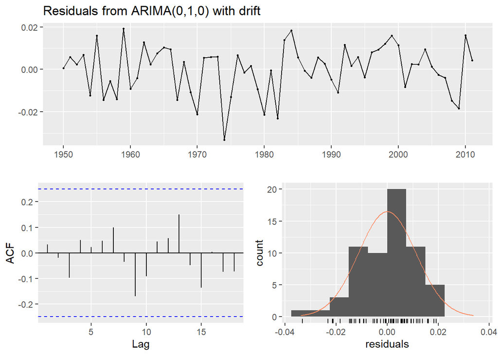

```
##
##  Ljung-Box test
##
## data:  Residuals from ARIMA(0,1,0) with drift
## Q* = 4.69, df = 9, p-value = 0.8604
##
## Model df: 1.   Total lags used: 10
```

```r
checkresiduals(fit_arimau)
```

```r
sqrt(0.0001291)
```

```
## [1] 0.01136222
```

# FORECAST

### Mexico - ETS

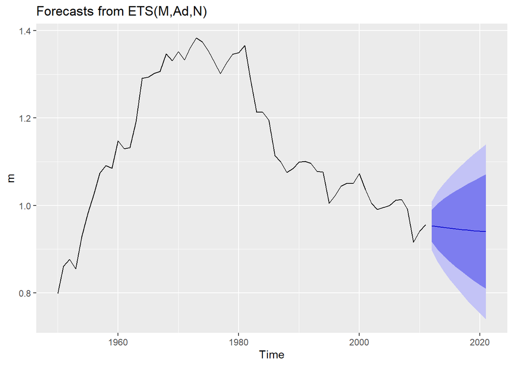

```r
fcstm <- forecast(fit_etsm, h=10)
autoplot(fcstm)
```

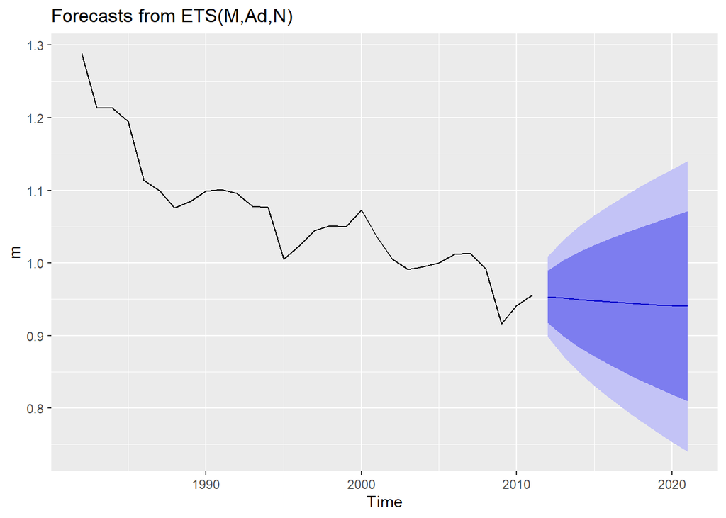

```r
autoplot(fcstm, include=30)
```

```r
print(summary(fcstm))
```

```
##
## Forecast method: ETS(M,Ad,N)
##
## Model Information:
## ETS(M,Ad,N)
##
## Call:
##  ets(y = m)
##
##   Smoothing parameters:
##     alpha = 0.9999
##     beta  = 0.0414
##     phi   = 0.9207
##
##   Initial states:
##     l = 0.7468
##     b = 0.0553
##
##   sigma:  0.0298
##
##       AIC      AICc       BIC
## -158.6524 -157.1251 -145.8896
##
## Error measures:
##                        ME       RMSE        MAE        MPE     MAPE     MASE
## Training set -0.005014125 0.03212635 0.02454934 -0.4674131 2.216226 0.925362
##                    ACF1
## Training set 0.07186068
##
## Forecasts:
##      Point Forecast     Lo 80     Hi 80     Lo 95    Hi 95
## 2012      0.9535776 0.9172091 0.9899461 0.8979568 1.009198
## 2013      0.9515646 0.8991853 1.0039439 0.8714574 1.031672
## 2014      0.9497113 0.8844543 1.0149684 0.8499093 1.049513
## 2015      0.9480050 0.8714370 1.0245731 0.8309043 1.065106
## 2016      0.9464341 0.8595351 1.0333330 0.8135336 1.079335
## 2017      0.9449877 0.8484472 1.0415283 0.7973417 1.092634
## 2018      0.9436561 0.8379961 1.0493160 0.7820631 1.105249
## 2019      0.9424300 0.8280675 1.0567926 0.7675276 1.117332
## 2020      0.9413013 0.8185818 1.0640207 0.7536181 1.128984
## 2021      0.9402620 0.8094810 1.0710431 0.7402496 1.140274
##      Point Forecast     Lo 80     Hi 80     Lo 95    Hi 95
## 2012      0.9535776 0.9172091 0.9899461 0.8979568 1.009198
## 2013      0.9515646 0.8991853 1.0039439 0.8714574 1.031672
## 2014      0.9497113 0.8844543 1.0149684 0.8499093 1.049513
## 2015      0.9480050 0.8714370 1.0245731 0.8309043 1.065106
## 2016      0.9464341 0.8595351 1.0333330 0.8135336 1.079335
## 2017      0.9449877 0.8484472 1.0415283 0.7973417 1.092634
## 2018      0.9436561 0.8379961 1.0493160 0.7820631 1.105249
## 2019      0.9424300 0.8280675 1.0567926 0.7675276 1.117332
## 2020      0.9413013 0.8185818 1.0640207 0.7536181 1.128984
## 2021      0.9402620 0.8094810 1.0710431 0.7402496 1.140274
```

### Canada - ARIMA

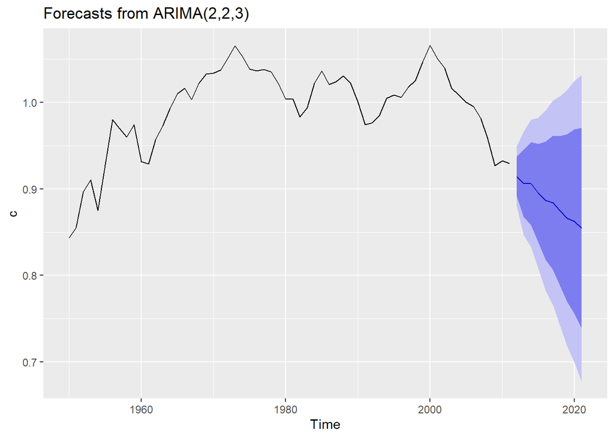

```r
fcstc <- forecast(fit_arimac, h=10)
autoplot(fcstc)
```

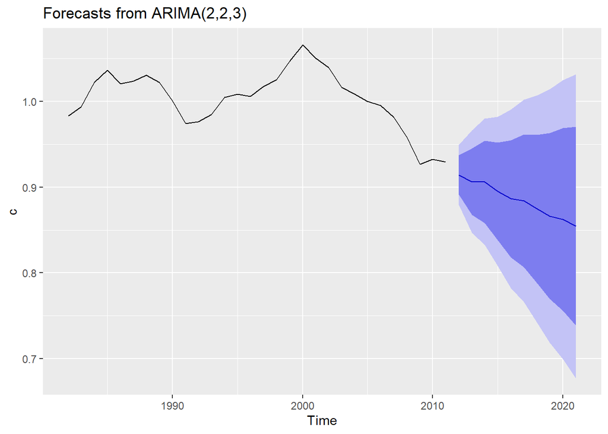

```r
autoplot(fcstc, include=30)
```

```r
print(summary(fcstc))
```

```
##
## Forecast method: ARIMA(2,2,3)
##
## Model Information:
## Series: c
## ARIMA(2,2,3)
##
## Coefficients:
##          ar1      ar2     ma1      ma2      ma3
##       -0.767  -0.7359  0.1481  -0.2723  -0.6061
## s.e.   0.202   0.1921  0.2337   0.2326   0.1862
##
## sigma^2 estimated as 0.0003181:  log likelihood=157.94
## AIC=-303.88   AICc=-302.29   BIC=-291.31
##
## Error measures:
##                        ME       RMSE       MAE        MPE     MAPE      MASE
## Training set -0.003233255 0.01679776 0.0129007 -0.3334222 1.317497 0.8577102
##                      ACF1
## Training set -0.003738827
##
## Forecasts:
##      Point Forecast     Lo 80     Hi 80     Lo 95     Hi 95
## 2012      0.9143242 0.8914681 0.9371803 0.8793688 0.9492796
## 2013      0.9064101 0.8674385 0.9453818 0.8468081 0.9660121
## 2014      0.9062905 0.8582550 0.9543260 0.8328265 0.9797545
## 2015      0.8949184 0.8380134 0.9518234 0.8078897 0.9819471
## 2016      0.8864416 0.8183608 0.9545225 0.7823210 0.9905623
## 2017      0.8840243 0.8067829 0.9612657 0.7658938 1.0021548
## 2018      0.8748286 0.7886226 0.9610346 0.7429880 1.0066693
## 2019      0.8663733 0.7697144 0.9630322 0.7185462 1.0142003
## 2020      0.8623379 0.7559731 0.9687027 0.6996670 1.0250089
## 2021      0.8543676 0.7384679 0.9702672 0.6771144 1.0316208
##      Point Forecast     Lo 80     Hi 80     Lo 95     Hi 95
## 2012      0.9143242 0.8914681 0.9371803 0.8793688 0.9492796
## 2013      0.9064101 0.8674385 0.9453818 0.8468081 0.9660121
## 2014      0.9062905 0.8582550 0.9543260 0.8328265 0.9797545
## 2015      0.8949184 0.8380134 0.9518234 0.8078897 0.9819471
## 2016      0.8864416 0.8183608 0.9545225 0.7823210 0.9905623
## 2017      0.8840243 0.8067829 0.9612657 0.7658938 1.0021548
## 2018      0.8748286 0.7886226 0.9610346 0.7429880 1.0066693
## 2019      0.8663733 0.7697144 0.9630322 0.7185462 1.0142003
## 2020      0.8623379 0.7559731 0.9687027 0.6996670 1.0250089
## 2021      0.8543676 0.7384679 0.9702672 0.6771144 1.0316208
```

### USA - ARIMA

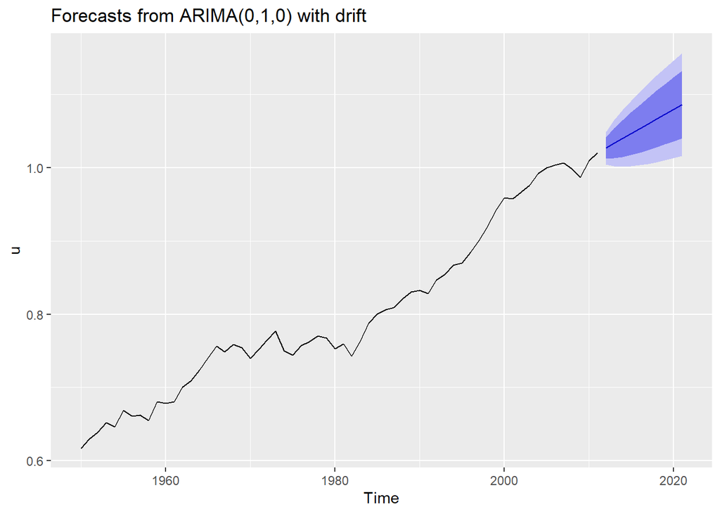

```r
fcstu <- forecast(fit_arimau, h=10)
autoplot(fcstu)
```

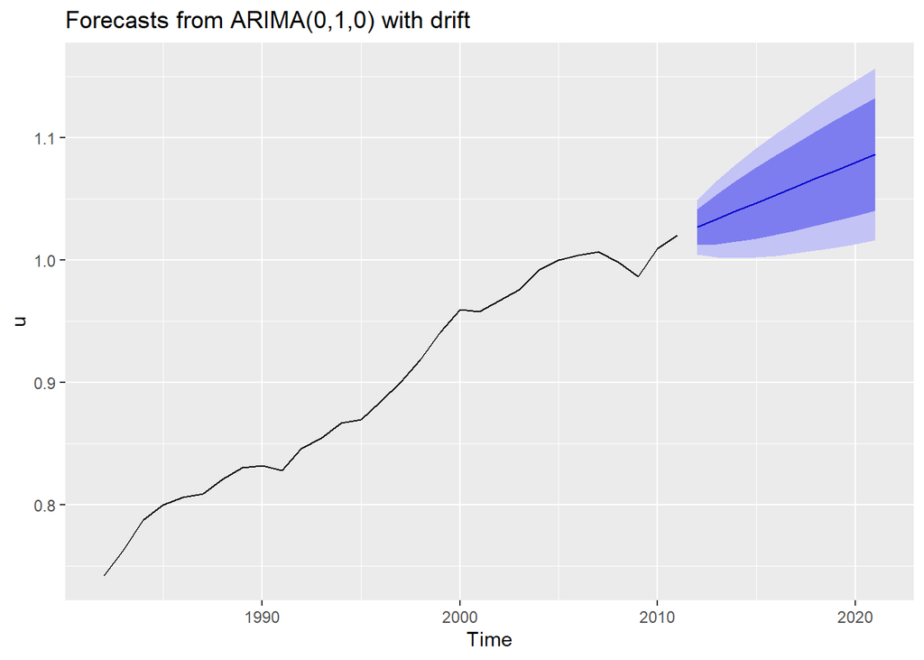

```r
autoplot(fcstu, include=30)
```

```r
print(summary(fcstu))
```

```
##
## Forecast method: ARIMA(0,1,0) with drift
##
## Model Information:
## Series: u
## ARIMA(0,1,0) with drift
##
## Coefficients:
##        drift
##       0.0066
## s.e.  0.0014
##
## sigma^2 estimated as 0.0001291:  log likelihood=187.09
## AIC=-370.17   AICc=-369.97   BIC=-365.95
##
## Error measures:
##                        ME       RMSE         MAE         MPE     MAPE     MASE
## Training set 9.847371e-06 0.01117543 0.009022366 -0.02282104 1.154826 0.799736
##                    ACF1
## Training set 0.03225483
##
## Forecasts:
##      Point Forecast    Lo 80    Hi 80    Lo 95    Hi 95
## 2012       1.027002 1.012444 1.041561 1.004737 1.049268
## 2013       1.033613 1.013024 1.054202 1.002125 1.065101
## 2014       1.040223 1.015007 1.065440 1.001659 1.078788
## 2015       1.046834 1.017717 1.075951 1.002303 1.091365
## 2016       1.053445 1.020891 1.085999 1.003657 1.103232
## 2017       1.060055 1.024394 1.095716 1.005516 1.114594
## 2018       1.066666 1.028147 1.105184 1.007757 1.125575
## 2019       1.073276 1.032098 1.114454 1.010300 1.136253
## 2020       1.079887 1.036211 1.123563 1.013090 1.146683
## 2021       1.086497 1.040459 1.132536 1.016088 1.156907
##      Point Forecast    Lo 80    Hi 80    Lo 95    Hi 95
## 2012       1.027002 1.012444 1.041561 1.004737 1.049268
## 2013       1.033613 1.013024 1.054202 1.002125 1.065101
## 2014       1.040223 1.015007 1.065440 1.001659 1.078788
## 2015       1.046834 1.017717 1.075951 1.002303 1.091365
## 2016       1.053445 1.020891 1.085999 1.003657 1.103232
## 2017       1.060055 1.024394 1.095716 1.005516 1.114594
## 2018       1.066666 1.028147 1.105184 1.007757 1.125575
## 2019       1.073276 1.032098 1.114454 1.010300 1.136253
## 2020       1.079887 1.036211 1.123563 1.013090 1.146683
## 2021       1.086497 1.040459 1.132536 1.016088 1.156907
```

- As shown above, for Mexico, the best model was the ETS (M, Ad, N) which has a stable and slightly decreasing trend for the coming years. For Canada, ARIMA showed a lower value for its waste and, the trend for the coming years, similarly to Mexico, shows a downward trend, however, a little more accentuated. Finally, in the USA, ARIMA was also the model that best fit this country, and, unlike the one analyzed in the previous two, this country has an increasing trend in TFP.

### Plotando os gráficos lado a lado para comparação

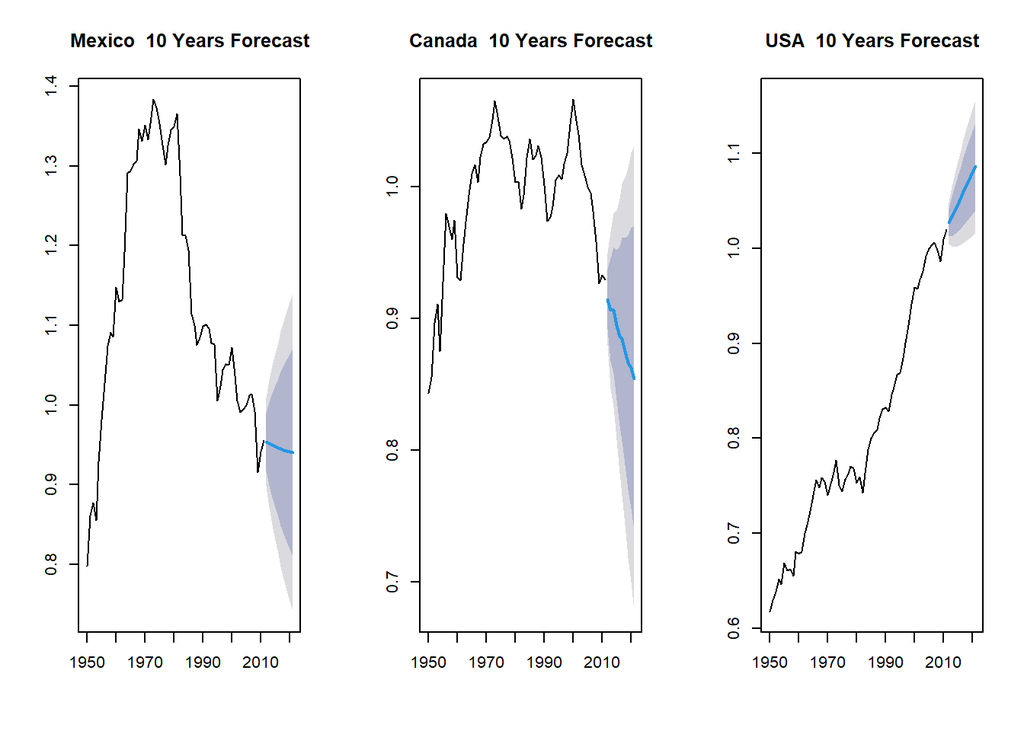

```r
par(mfrow= c(1,3))
plot(fcstm, main = 'Mexico  10 Years Forecast')
plot(fcstc, main = 'Canada  10 Years Forecast')
plot(fcstu, main = 'USA  10 Years Forecast')
```

* Besides these analysis, there are other variables that could explain the TFP series as we could see in this link: https://cran.r-project.org/web/packages/pwt8/pwt8.pdf. Observing the original list of variables, for explaining the TFP behavior, we have to focous on productivity. Productivity is related to GPD, so we have to find variabeles that are related with GPD. So, it would be helpful:

- hc - Index of human capital per person, based on years of schooling (Barro and Lee 2013) and returns to education (Psacharopoulos 1994).
- rkna - Capital stock at constant 2005 national prices (in million 2005 USD).
- csh_x - Share of merchandise exports at current PPPs.
- csh_m - Share of merchandise imports at current PPPs.